# Wprowadzenie do obliczeń w Pythonie

Krzysztof Trajkowski

2017-03-07

# 1 Wprowadzenie

## 1.1 Wersje Pythona

Na początek warto podkreślić, że równolegle są dostępne dwie wersje Pythona tzn. 2.x (aktualna stabilna wersja to 2.7.12) oraz 3.x (aktualne stabilna wersja to 3.5.2).

Aby skorzystać z wersji Pythona 2.x w konsoli systemowej (dystrybucje linuksa) należy wpisać komendę `python` lub `python2` (ewentualnie `python3` dla wersji 3.x) i zatwierdzić enterem. Python jest domyślnie instalowany w systemach linuksowych wraz z dystrybucją. Dotyczy to także Mac OS X.

Więcej szczegółowych informacji można znaleźć po adresem:

- http://python.edu.pl/byteofpython/2.x/03.html

W tym poradniku będziemy korzystać z wersji 3.5.2. Po drobnych modyfikacjach kod zamieszczony w tym dokumencie powinien działać w Pythonie 2.7.12. Różnice pomiędzy wersjami nie są zbyt duże. Jedną z nich przedstawimy na przykładzie operatora arytmetycznego dzielenia.

```python
# Python 3:
print (4/7)
```

```
## 0.5714285714285714
```

Aby uzyskać poprawny wynik dzielenia w Pythonie 2.x należy przedstawić przynajmniej jedną liczbę w formie dziesiętnej:

```python
# Python 2:
print 4/7.
```

```
## 0.571428571429
```

lub na początku kodu dodać poniższą instrukcję:

```python
# Python 2:
from __future__ import division
print 4/7
```

```
## 0.571428571429
```

Więcej informacji na ten temat można znaleźć pod adresami:

- http://sebastianraschka.com/Articles/2014_python_2_3_key_diff.html#python-2-2
- https://wiki.python.org/moin/Python2orPython3

## 1.2 Środowiska programistyczne

Pisanie komend bezpośrednio w konsoli programu nie jest optymalnym rozwiązaniem – szczególnie gdy mamy dużą ilość kodu. W takich sytuacjach warto pisać kod w pliku tekstowym i za pomocą funkcji `exec` uruchomić skrypt w Pythonie. Poniżej przykład dla skryptu o nazwie FUN.py:

```
>>> exec(open('/FUN.py').read())
```

lub z poziomu konsoli systemowej:

```
python3 '/FUN.py'
```

Innym bardzo wygodnym rozwiązaniem jest skorzystanie z edytora Spyder – dla każdej wersji Pythona jest oddzielna wersja Spaydera.

- https://github.com/spyder-ide/spyder.

Warto też wspomnieć o środowisku Jupyter dzięki któremu nie musimy ograniczać się tylko do języka Python. Poniżej instrukcja jego instalacji.

```
pip3 install jupyter
```

Należy pamiętać aby wcześniej zainstalować instalator pakietów `pip3`. Poniżej przykład jak to zrobić w systemie Linux - dystrybucja Ubuntu dla Pythona 3.5.2:

```
sudo apt-get install python3-pip
```

Po wpisaniu w konsoli systemowej:

```
ipython3 notebook
```

zostanie uruchomiony notatnik Jupyter.

Więcej informacji można znaleźć pod adresem:

- http://perseba.github.io/blog/jupyter-wprowadzenie.html

## 1.3 Pakiety

Funkcjonalność języka Python możemy rozszerzać o dodatkowe biblioteki – http://www.scipy.org/. Poniżej zostaną wymienione niektóre z nich:

- *SymPy* – obliczenia symboliczne,
- *SciPy* – obliczenia numeryczne, rozszerzenie możliwości pakietu *NumPy*,
- *Pandas* – odczyt/zapis i przekształcanie zbiorów danych,
- *matplotlib* – generowanie wykresów.

Aby zainstalować dowolny pakiet np. *SymPy* wystarczy wpisać poniższą komendę:

```
pip3 install sympy
```

Import wybranego pakietu można dokonać na kilka sposobów. Poniżej przykład jak załadować dwie biblioteki *SymPy* oraz *SciPy* aby obliczyć: $\sqrt{5}$. Zaznaczmy, że w podstawowej wersji Pythona nie ma wbudowanej funkcji do obliczeń pierwiastków kwadratowych.

```python
from sympy import *
from scipy import *

print (sqrt(5))
```

```
## 2.2360679775
```

Gwiazdka oznacza, że importujemy wszystkie funkcje. Oczywiście jest możliwość aby wybrać tylko te które nas interesują. Jednak nazwy funkcji z różnych pakietów mogą się dublować. Na przykład funkcja *sqrt* jest w pakiecie *SymPy* oraz *SciPy*. W takich przypadkach będziemy mogli korzystać tylko z funkcji z ostatnio załadowanego pakietu tzn. *SciPy*. Aby zapobiec takiej sytuacji lepiej użyć innego sposobu.

```python
import sympy
import scipy

print (sympy.sqrt(5))
print (scipy.sqrt(5))
```

```
## sqrt(5)
## 2.2360679775
```

Dzięki takiemu zabiegowi musimy zawsze deklarować z jakiej biblioteki będzie użyta funkcja. Inaczej mówiąc poprzedzamy nazwę funkcji (np. `sqrt`) nazwą pakietu z jakiego pochodzi. Aby zapobiec wpisywania za każdym razem całej nazwy pakietu można mu przypisać własną nazwę. Poniżej sytuacja w której dla funkcji `sqrt` z pakietu *SymPy* nie odwołujemy się do nazwy biblioteki. Natomiast w przypadku korzystania z funkcji z pakietu *SciPy* już tak ale wykorzystujemy do tego celu własną nazwę.

```python
from sympy import *
import scipy as sc

print (sqrt(5))
print (sc.sqrt(5))
```

```
## sqrt(5)
## 2.2360679775
```

Cechą charakterystyczą pakietu *SciPy* jest to, że zawiera on wszystkie funkcje z biblioteki *NumPy*. Dodatkowo posiada tzw. subpakiety które należy oddzielnie importować. Poniżej przykład załadowania subbiblioteki *scipy.special* zawierającej funkcje specjalne. Poniżej obliczona wartość funkcji gamma dla argumentu: 2.17.

```python
import scipy.special as spec

print (spec.gamma(2.17))
```

```
## 1.08423854442
```

Aby sprawdzić jaka jest zainstalowana wersja pakietu np. *matplotlib* należy użyć poniższej komendy:

```python
import pkg_resources

print (pkg_resources.get_distribution("matplotlib").version)
```

```
## 2.0.0
```

Aby zaktualizować pakiet np. *matplotlib* należy użyć poniższej komendy:

```
pip3 install --upgrade matplotlib
```

Wiele dodatkowych informacji na temat Pythona można znaleźć pod adresem:

- http://python101.readthedocs.io/pl/latest/index.html#

# 2 Zbiory danych

## 2.1 Ramka danych

Poniżej przykładowa ramka danych i jej zapis do pliku tekstowego *FUNDACJA.csv*:

```python
import pandas as pd

f = pd.DataFrame({'X' :[1.2, 5.6, 5.8, 3.1], 'Y' :[1, 6, 8, 7]})
f.to_csv('FUNDACJA.csv')
```

Alternatywą do powyższego zapisu może być zapis:

```python
import pandas as pd

f = pd.DataFrame()
f['X'] = [1.2, 5.6, 5.8, 3.1]
f['Y'] = [1, 6, 8, 7]
f.to_csv('FUNDACJA.csv')
```

Za pomocą pakietu `pandas` możemy zapisywać (wczytywać) dane także w innych formatach. Służą do tego funkcje: `read_excel` (arkusz kalkulacyjny excel), `read_sas` (pakiet SAS) i `read_stata` (pakiet STATA).

## 2.2 Przekształcanie danych

Podczas pracy z danymi istotną rolę odgrywają funkcje które umożliwiają czyszczenie i przekształcanie danych. Poniżej przykłady kilku podstawowych operacji na danych z pakietem `pandas`.

- jak otworzyć zbiór danych z pliku .csv ?

```python
import pandas as pd

df = pd.read_csv("PKN.csv")[['Data','Zmiana']]
print(df.head(3))
```

```
##          Data    Zmiana
## 0  2010:10:29 -0.005951
## 1  2010:11:02  0.014706
## 2  2010:11:03  0.013047
```

- jak zamienić wszystkie znaki `:` na `-` ?

```python
import pandas as pd

df = pd.read_csv("PKN.csv")[['Data','Zmiana']]
df['Data'] = df['Data'].str.replace(':','-')
print(df.head(3))
df.to_csv('PKN_v01.csv',index=False)
```

```
##          Data    Zmiana
## 0  2010-10-29 -0.005951
## 1  2010-11-02  0.014706
## 2  2010-11-03  0.013047
```

- jak dodać na końcu liczb znak `%` ?

```python
import pandas as pd

df = pd.read_csv("PKN_v01.csv")
df['Procent'] = round(df['Zmiana']*100,4).astype(str) + ' %'
print(df.head())
```

```
##          Data    Zmiana    Procent
## 0  2010-10-29 -0.005951  -0.5951 %
## 1  2010-11-02  0.014706   1.4706 %
## 2  2010-11-03  0.013047   1.3047 %
## 3  2010-11-04  0.060104   6.0104 %
## 4  2010-11-05  0.031256   3.1256 %
```

- jak rozdzielić kolumnę `Data` na trzy inne ?

```python
import pandas as pd

df = pd.read_csv("PKN_v01.csv")
df = df.join(df['Data'].str.split('-', 2, expand=True).\
     rename(columns={0:'Rok', 1:'Miesiac', 2:'Dzien'}))
print(df.head())
df.to_csv('PKN_v02.csv',index=False)
```

```
##          Data    Zmiana   Rok Miesiac Dzien
## 0  2010-10-29 -0.005951  2010      10    29
## 1  2010-11-02  0.014706  2010      11    02
## 2  2010-11-03  0.013047  2010      11    03
## 3  2010-11-04  0.060104  2010      11    04
## 4  2010-11-05  0.031256  2010      11    05
```

- jak scalić dwie kolumny `Rok` i `Miesiąc` w jedną ?

```python
import pandas as pd

df = pd.read_csv("PKN_v02.csv")
df['Data'] = df['Rok'].astype(str)  + '-' + df['Miesiac'].astype(str)
print(df.head())
```

```
##       Data    Zmiana   Rok  Miesiac  Dzien
## 0  2010-10 -0.005951  2010       10     29
## 1  2010-11  0.014706  2010       11      2
## 2  2010-11  0.013047  2010       11      3
## 3  2010-11  0.060104  2010       11      4
## 4  2010-11  0.031256  2010       11      5
```

- jak przekształcać daty ?

```python
import pandas as pd
import datetime
import time

df = pd.read_csv("PKN_v02.csv")
df['Data'] = pd.to_datetime(df['Data'])
df['Miesiac'] = df['Data'].apply(lambda x: x.strftime('%B'))
df['Dzien'] = df['Data'].apply(lambda x: x.strftime('%A'))
print(df.head(3))
df.iloc[:,1:5].to_csv('PKN_v03.csv',index=False)
```

```
##         Data    Zmiana   Rok   Miesiac      Dzien
## 0 2010-10-29 -0.005951  2010   October     Friday
## 1 2010-11-02  0.014706  2010  November    Tuesday
## 2 2010-11-03  0.013047  2010  November  Wednesday
```

- jak grupować dane ?

```python
import pandas as pd

df = pd.read_csv("PKN_v03.csv")
df = df.groupby(['Rok','Miesiac','Dzien'],as_index=False)['Zmiana'].agg({'zm' : 'mean'})
print(df.head())
```

```
##     Rok   Miesiac      Dzien        zm
## 0  2010  December     Friday -0.007143
## 1  2010  December     Monday -0.003315
## 2  2010  December   Thursday  0.003981
## 3  2010  December    Tuesday  0.006987
## 4  2010  December  Wednesday  0.004976
```

Do agregowania danych zamiast pakietu `pandas` możemy używać także biblioteki `dplython` która jest wzorowana na pakiecie `dplyr` dla języka R.

```python
from dplython import *
import pandas as pd

df = DplyFrame(pandas.read_csv('PKN_v03.csv'))
DF = df >> group_by(X.Rok,X.Miesiac,X.Dzien) >> summarize(zm = X.Zmiana.mean())
print(DF.head())
```

```
##     Rok   Miesiac      Dzien        zm
## 0  2010  December     Friday -0.007143
## 1  2010  December     Monday -0.003315
## 2  2010  December   Thursday  0.003981
## 3  2010  December    Tuesday  0.006987
## 4  2010  December  Wednesday  0.004976
```

- jak utworzyć szereg czasowy ?

```python
import pandas as pd
from datetime import datetime

df = pd.read_csv("PKN_v02.csv")[['Data','Zmiana']]
df['Data'] = pd.to_datetime(df['Data'])
df.index = df['Data']
del df['Data']
print(df.head(3))
```

```
##               Zmiana
## Data
## 2010-10-29 -0.005951
## 2010-11-02  0.014706
## 2010-11-03  0.013047
```

Dzięki pakietowi `pandas_datareader.data` mamy dostęp do wielu ciekawych zbiorów danych dostępnych w internecie. Możemy pobierać dane z Eurostatu, Bank Światowego, OECD, serwisów internetowych np. Oanda, Yahoo!Finanse i inne.

Więcej informacji można znaleźć pod adresem:

- https://pandas-datareader.readthedocs.io/en/latest/whatsnew.html

# 3 Grafika

## 3.1 Wykresy klasyczne

- Jak narysować wykres liniowy?

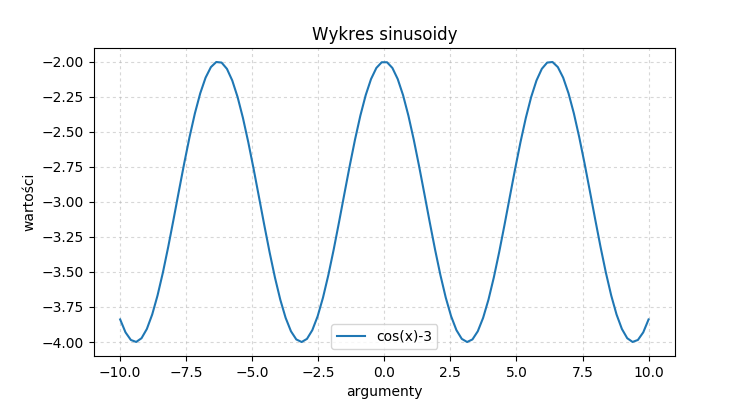

```python
from scipy import *
import matplotlib.pyplot as plt

xdata = linspace(-10,10, 100)
x = linspace(-10,10, 10)
plt.figure(figsize=(7.5,4))
plt.grid(True, alpha=0.5, linestyle=':')
plt.title('Wykres sinusoidy')
plt.plot(xdata, cos(xdata)-3, label='cos(x)-3')
plt.xlabel('argumenty')
plt.ylabel('wartości')
plt.legend()
plt.savefig('matplotlib01.png')
```

- Jak narysować wykres paskowy?

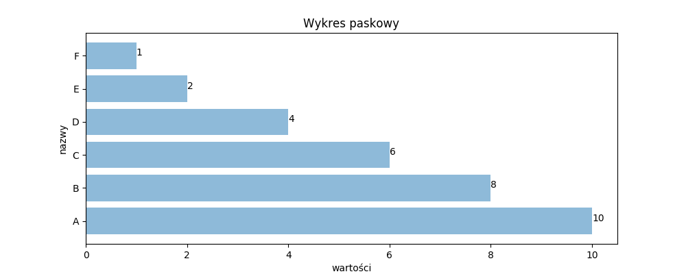

```python
from scipy import *
import matplotlib.pyplot as plt

objects = ('A', 'B', 'C', 'D', 'E', 'F')
y_pos = arange(len(objects))
performance = [10,8,6,4,2,1]

plt.figure(figsize=(10,4))
plt.barh(y_pos, performance, align='center', alpha=0.5)
plt.yticks(y_pos, objects)
for a,b in zip(performance, y_pos):
    plt.text(a,b, str(a))
plt.xlabel('wartości')
plt.ylabel('nazwy')
plt.title('Wykres paskowy')
plt.savefig('paski01.png')
```

- Jak narysować wykres krzywej?

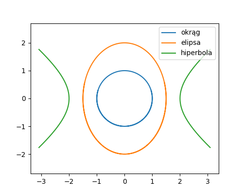

```python
from scipy import *
import matplotlib.pyplot as plt

plt.figure(figsize=(5,4))
t = linspace(-5,5,1000)
plt.plot(sin(t), cos(t), label='okrąg')
plt.plot(1.5*sin(t), 2*cos(t), label='elipsa')
t = linspace(-1,1,1000)
plt.plot(2*cosh(t), 1.5*sinh(t), color='C2',label='hiperbola')
plt.plot(-2*cosh(t), -1.5*sinh(t), color='C2')
plt.axes().set_aspect('equal', 'datalim')
plt.legend()
plt.savefig('krzywe01.png')
```

- Jak rozmieszczać osie?

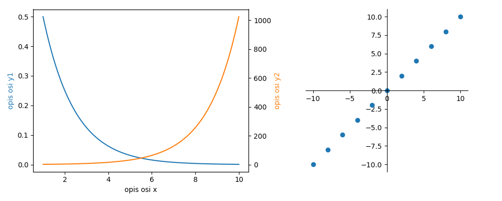

```python
from scipy import *
import matplotlib.pyplot as plt

x = linspace(1,10, 100)
y = 2**(-x)
z = 2**x

fig = plt.figure(figsize=(10,4))
ax1 = fig.add_subplot(1, 2, 1)
ax2 = ax1.twinx()
ax1.plot(x,y,color='C0',label='f(x)')
ax2.plot(x,z,color='C1',label='g(x)')
ax1.set_ylabel('opis osi y1', color='C0')
ax2.set_ylabel('opis osi y2', color='C1')
ax1.set_xlabel('opis osi x')
ax = plt.subplot(1, 2, 2, aspect='equal')
ax = plt.gca()
ax.plot(linspace(-10,10, 11), linspace(-10,10, 11),'o')
ax.spines['left'].set_position('zero')
ax.spines['right'].set_color('none')
ax.spines['bottom'].set_position('zero')
ax.spines['top'].set_color('none')
plt.tight_layout()
plt.savefig('osie01.png')
```

- Jak narysować szereg czasowy?

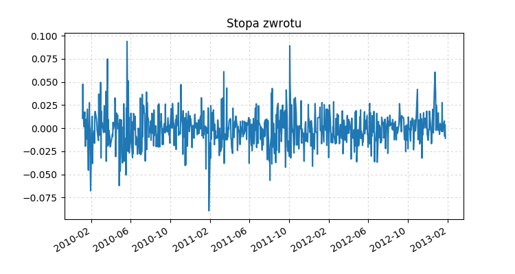

```python
from scipy import *
import matplotlib.pyplot as plt
from matplotlib import dates
import pandas_datareader.data as web
import pandas as pd
from datetime import datetime
import scipy.stats as stats

start = datetime(2010, 1, 1)
end = datetime(2013, 1, 27)
dft = web.DataReader("F", 'yahoo', start, end)
dft['return'] = log(dft['Close']/dft['Open'])

plt.figure(figsize=(7.5,4))
plt.grid(True, alpha=0.5, linestyle=':')
plt.title('Stopa zwrotu')
plt.plot(dft['return'])
plt.gcf().autofmt_xdate()
plt.savefig('matplotlib02.png')
```

## 3.2 Wykresy niestandardowe

- Jak narysować wykres wiolinowy?

```
##     sepal_length  sepal_width  petal_length  petal_width species
## 0            5.1          3.5           1.4          0.2  setosa
## 1            4.9          3.0           1.4          0.2  setosa
## 2            4.7          3.2           1.3          0.2  setosa
## 3            4.6          3.1           1.5          0.2  setosa
## 4            5.0          3.6           1.4          0.2  setosa
## 5            5.4          3.9           1.7          0.4  setosa
## 6            4.6          3.4           1.4          0.3  setosa
## 7            5.0          3.4           1.5          0.2  setosa
## 8            4.4          2.9           1.4          0.2  setosa
## 9            4.9          3.1           1.5          0.1  setosa
## 10           5.4          3.7           1.5          0.2  setosa
## 11           4.8          3.4           1.6          0.2  setosa
```

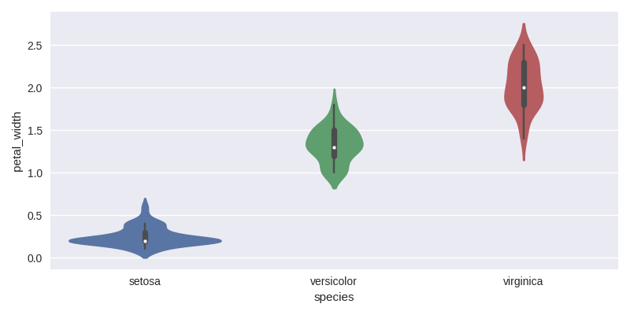

```python
import warnings
warnings.filterwarnings("ignore")

import seaborn as sns
import matplotlib.pyplot as plt

iris = sns.load_dataset("iris")
print(iris.head(12))

plt.figure(figsize=(8,4))
sns.violinplot(x = 'species', y = 'petal_width', data = iris)
plt.tight_layout()
plt.savefig('seaborn01.png')
```

- Jak narysować boxplot z podziałem na grupy?

```
##    total_bill   tip     sex smoker  day    time  size
## 0       16.99  1.01  Female     No  Sun  Dinner     2
## 1       10.34  1.66    Male     No  Sun  Dinner     3
## 2       21.01  3.50    Male     No  Sun  Dinner     3
## 3       23.68  3.31    Male     No  Sun  Dinner     2
```

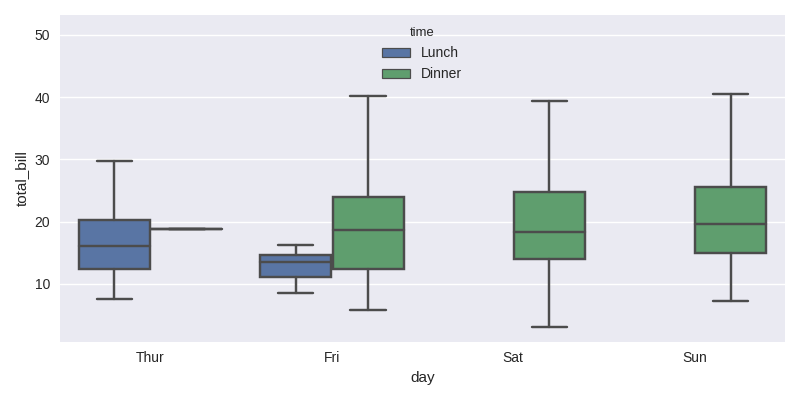

```python
import warnings
warnings.filterwarnings("ignore")

import seaborn as sns
import matplotlib.pyplot as plt

tips = sns.load_dataset("tips")
print(tips.head(4))

plt.figure(figsize=(8,4))
sns.boxplot(x="day", y="total_bill", hue="time", data=tips)
plt.tight_layout()
plt.savefig('seaborn02.png')
```

# 4 Elementy matematyki

## 4.1 Pochodna

Wyznaczenie postaci analitycznej pochodnej funkcji nie jest zawsze możliwe. Za przykład niech posłuży funkcja błędu o postaci:
$$f(x)=\frac{2}{\sqrt{\pi}}\int_{0}^{x}\exp(-t^2)\;dt$$
W takiej sytuacji można wykorzystać metody numeryczne aby naszkicować wykres pochodnej funkcji. Poniżej przykład jak to zrobić.

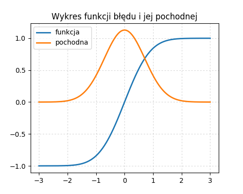

```python
from scipy import *
import matplotlib.pyplot as plt
import scipy.special as spec
from scipy.misc import derivative

f = lambda x: spec.erf(x)
d = lambda x: derivative(f, x, dx=1e-6)

plt.figure(figsize=(5,4))
plt.grid(True, alpha=0.5, linestyle=':')
plt.title('Wykres funkcji błędu i jej pochodnej')
X = linspace(-3, 3, 500)
plt.plot(X,f(X), linewidth=2,label='funkcja')
plt.plot(X,d(X), linewidth=2,label='pochodna')
plt.legend()
plt.savefig('pochodna01.png')
```

## 4.2 Miejsce zerowe

Miejsca zerowe pewnych funkcji nie można wyznaczyć za pomocą obliczeń symbolicznych. W takich sytuacjach dobrze sprawdzają się metody numeryczne: `brentq`, `brenth`, `ridder`, `bisect`, `newton`. Poniżej przykład z wykorzystaniem funkcji `newton`.

$$f(x)=x^2-3^x+2$$

```
## 1.0
```

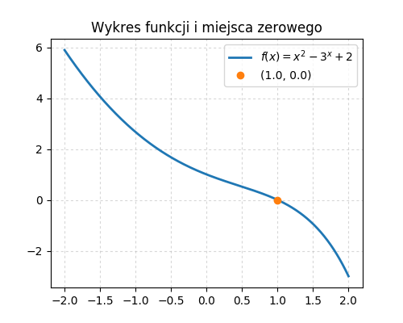

```python
from scipy import *
from scipy.optimize import *
import matplotlib.pyplot as plt

f = lambda x: x**2-3**x+2
sol = newton(f, 1)
print (sol)

plt.figure(figsize=(5,4))
plt.grid(True, alpha=0.5, linestyle=':')
plt.title('Wykres funkcji i miejsca zerowego')
X = linspace(-2,2, 500)
plt.plot(X,f(X), linewidth=2,label=r'$f(x)=x^2-3^x+2$')
plt.plot(sol,0,'o',label='(%.1f, %.1f)' % (sol,f(sol)))
plt.legend()
plt.savefig('mz01.png')
```

## 4.3 Układ równań

Do rozwiązywania nieliniowych układów równań służą dwie funkcje: `fsolve` oraz `root` z pakietu `scipy.optimize` – często są też wykorzystywane do obliczania miejsc zerowych funkcji. Poniżej przykład rozwiązania układu równań o postaci:
$$\begin{cases} y=x^{-x} \\ y=x^x-2.2 \end{cases}$$

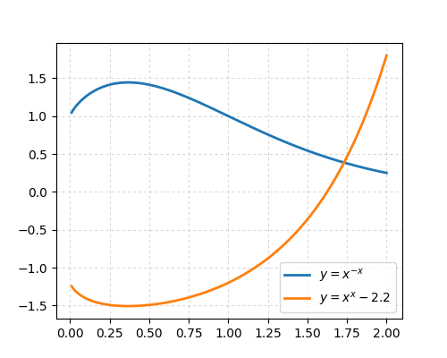

```python
from scipy import *
from scipy.optimize import *

def eq(X):
    x, y = X
    eq1 = x**(-x)-y
    eq2 = x**x-2.2-y
    return [eq1, eq2]

sol = fsolve(eq,[1.75,0.5]);
print (sol)
```

```
## [ 1.73135413  0.38660687]
```

Często się zdarza, że układ równań ma kilka rozwiązań. W takich sytuacjach wygodnie jest wykorzystać pętle `for` ponieważ funkcje `fsolve` i `root` mogą wykonać obliczenia tylko dla jednego punktu startowego. Za przykład posłuży nam układu równań o postaci:

$$\begin{cases} y=x^3-3x-2 \\ x=y^3-3y-2 \end{cases}$$

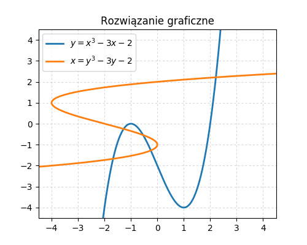

Na podstawie wykresu możemy założyć, że układ równań ma pięć rozwiązań. Zatem będziemy szukać tych współrzędnych na podstawie pięciu punktów startowych:
$$(2,2),\;(-1.5,-1.5),\;(-1,-0.5),\;(-0.5,-0.5),\;(-0.5,-1)$$

```python
from scipy import *
from scipy.optimize import *
from pandas import *

def eq(X):
    x, y = X
    eq1 = (x**3-3*x-2)-y
    eq2 = (y**3-3*y-2)-x
    return [eq1, eq2]

df = DataFrame({'x' :[2,-1.5,-1,-0.5,-0.5], 'y' :[2,-1.5,-0.5,-0.5,-1]})
sol = [ fsolve(eq, df.reindex([i]) ) for i in range(5) ]
df = DataFrame(sol, columns=['x','y'])
print (df)
```

```
##           x         y
## 0  2.214320  2.214320
## 1 -1.675131 -1.675131
## 2 -1.274551 -0.246829
## 3 -0.539189 -0.539189
## 4 -0.246829 -1.274551
```

W przypadku gdy nie wiemy jakie punkty startowe wybrać możemy zastosować symulację monte carlo z wykorzystaniem np. rozkładu jednostajnego. Tym razem obliczenia wykonamy za pomocą funkcji `root` dzięki której oprócz rozwiązania otrzymujemy kilka dodatkowych informacji np. o tym czy algorytm zakończył działanie pomyślnie: `success=True` lub nie: `success=False`. Wykorzystamy tę informacje do filtrowania uzyskanych rozwiązań.

```python
from scipy import *
from scipy.optimize import *
from pandas import *

def eq(X):
    x, y = X
    eq1 = (x**3-3*x-2)-y
    eq2 = (y**3-3*y-2)-x
    return [eq1, eq2]

B = 100
sol = [ root(eq, [random.uniform(-4,4,2)]) for i in range(B) ]
s = [ sol[i].success for i in range(B) ]
df = DataFrame({'s' :s})
S = [ sol[i].x for i in df[df['s'] == True].index.values ]
DF = DataFrame(S, columns=['x','y'])
DF = DF.round(3)
DF = DF.drop_duplicates()
print (DF)
```

```
##         x      y
## 0  -1.675 -1.675
## 1   2.214  2.214
## 14 -0.247 -1.275
## 15 -1.275 -0.247
## 20 -0.539 -0.539
```

## 4.4 Ekstremum

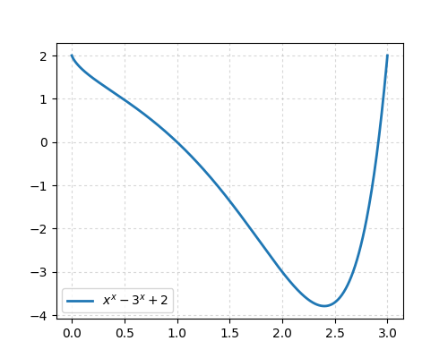

```python
from scipy import *
from scipy.optimize import *

f = lambda x: x**x-3**x+2

res = fminbound(f, 0,3)
fun = f(res)
print ('Dla argumentu x:', ("%.7f" % res), 'funkcja osiąga minimum:', ("%.7f" % fun))
```

```
## Dla argumentu x: 2.4007346 funkcja osiąga minimum: -3.7912525
```

## 4.5 Całka oznaczona

$$\int_{0.25}^{1}x^{x}$$

```python
from scipy import *
from scipy.integrate import *

f = lambda x: x**x

sol = quad(f, 0.25,1)
print (sol)
```

```
## (0.5851010692820607, 6.495926788497427e-15)
```

```python
from scipy import *

f = lambda x: x**x

sol = mean([f(random.uniform(0.25,1)) for x in range(10000)])*0.75
print (sol)
```

```
## 0.587143883309
```

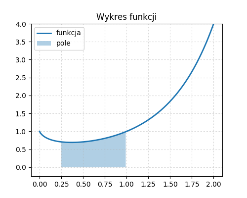

```python
from scipy import *
import matplotlib.pylab as plt

f = lambda x: x**x

a, b = 0.25, 1

x = linspace(0,2, 10000)
y = f(x)

plt.figure(figsize=(5,4))
plt.grid(True, alpha=0.5, linestyle=':')
plt.ylim(-0.25,4)
plt.title('Wykres funkcji')
plt.plot(x, y, linewidth = 2, label='funkcja')
plt.fill_between(x=arange(a,b,0.01), y1=f(arange(a,b,0.01)), alpha=0.35, label='pole')
plt.legend()
plt.savefig('calka01.png')
```

# 5 Optymalizacja

## 5.1 Funkcja six-hump camel

W przypadku gdy funkcja ma kilka wartości ekstremalnych (i chcemy je wszystkie znaleźć) to dobrym rozwiązaniem jest wykorzystanie symulacji monte carlo. Dla każdej interacji parametry startowe będą losowane z rozkładu jednostajnego z uwzględnieniem ograniczeń pudełkowych. Poniżej przykład z wykorzystaniem funkcji six-hump camel:
$$F({\bf{x}})=\left(4-2.1x_1^2+\frac{x_1^4}{3}\right)x_1^2+x_1x_2+(-4+4x_2^2)x_2^2$$
$$\left[\begin{array}{r}
-2\\[0.3em]
-1
\end{array}\right]
\leq{\bf{x}}\leq
\left[\begin{array}{r}
2\\[0.3em]
1
\end{array}\right]$$

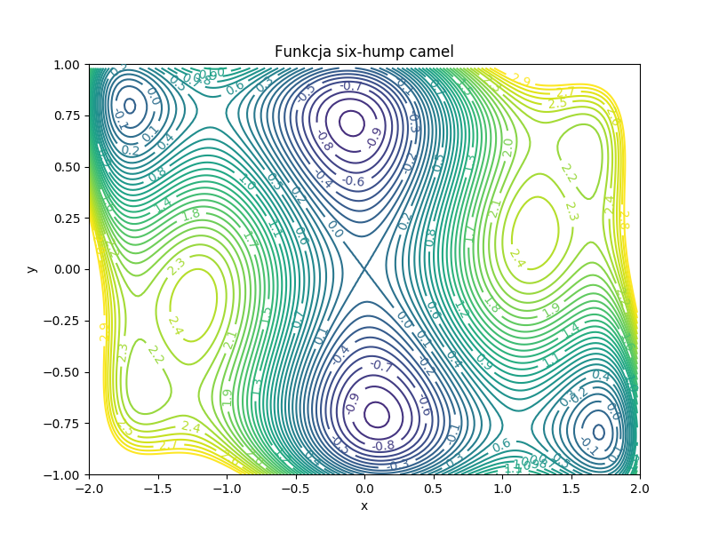

```python
from scipy import *
import matplotlib.pyplot as plt

plt.figure(figsize=(8,6))
delta = 0.02
x, y = meshgrid(arange(-2, 2, delta), arange(-1, 1, delta))
z = (4-2.1*x**2+x**4/3)*x**2+x*y+(-4+4*y**2)*y**2
levels = arange(-1.6,3.0,0.1)
CS = plt.contour(x, y, z, levels=levels)
plt.clabel(CS, fontsize=10, inline=1, fmt='%1.1f')
plt.title('Funkcja six-hump camel')
plt.xlim(-2, 2)
plt.ylim(-1, 1)
plt.xlabel('x')
plt.ylabel('y')
plt.savefig('camel01.png')
```

```python
from scipy import *
from scipy.optimize import *
from pandas import *

def F(x):
    return (4-2.1*x[0]**2+x[0]**4/3)*x[0]**2+x[0]*x[1]+(-4+4*x[1]**2)*x[1]**2

bnds = ((-2,2), (-1,1))
B = 300
res = [minimize(F, [random.randint(-1,1,1),random.randint(-2,2,1)],\
       method='L-BFGS-B', bounds=bnds)\
      for i in range(B) ]

Xv = [res[i]['x'] for i in range(B)]
Fv = [res[i]['fun'] for i in range(B)]
df = DataFrame(Xv, columns=['x1','x2'])
df = df.assign(Fv= Fv)
df = df.sort_values(by=['Fv'], ascending=[True])
df = df.round(2)
df = df.drop_duplicates()
print (df.head())
```

```
##        x1    x2    Fv
## 204  0.09 -0.71 -1.03
## 130 -0.09  0.71 -1.03
## 29   0.00  0.00  0.00
```

## 5.2 Funkcja Eggholder

W pakiecie `scipy.optimize` jest zaimplementowanych kilka stosunkowo nowych technik do optymalizacji funkcji nieliniowych. Wzorowane są na zjawiskach fizycznych lub są zaczerpnięte z obszaru nauk biologicznych. Przykładem może być metoda ewolucji różnicowej dla której źródłem inspiracji były procesy ewolucji występujące w przyrodzie – funkcja `differential_evolution`. Inną ciekawą techniką jest metoda symulowanego wyżarzania która powstała na podstawie obserwacji zjawiska wyżarzania w metalurgii. Sprawdza się ona dobrze w przypadku optymalizacji tzw. funkcji chropowatych (duża deformacja powierzchni) gdzie konwencjonalne metody gradientowe często mają problem ze znalezieniem minimum globalnego. Dobrą alternatywą dla tej metody jest technika “basin-hopping” – funkcja `basinhopping` która domyślnie wykorzystuje algorytm minimalizacji lokalnej `BFGS`. Poniżej przykład optymalizacji funkcji Eggholder – szukanie jej minimum:

$$F({\bf{x}})=-(x_2+47)\sin\left(\sqrt{\left|x_2+\frac{x_1}{2}+47\right|}\right)-x_1\sin\left(\sqrt{|x_1-(x_2+47)|}\right)$$
$$-512\leq{\bf{x}}\leq 512$$

```python
from scipy import *
from scipy.optimize import *

def F(x):
    return -(x[1]+47)*sin(sqrt(abs(x[1]+x[0]/2+47)))-x[0]*sin(sqrt(abs(x[0]-(x[1]+47))))

l_bfgs_b = {"method":"L-BFGS-B","bounds":[(-512,512),(-512,512)]}
res = basinhopping(F, (1,1), minimizer_kwargs=l_bfgs_b, niter=5000)
print (res.x)
print (res.fun)
```

[output not shown]

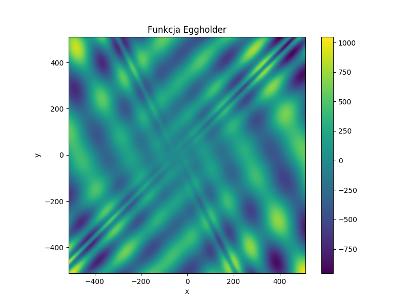

```python
from scipy import *
import matplotlib.pyplot as plt

plt.figure(figsize=(8,6))
x, y = mgrid[-512:512, -512:512]
z = -(y+47)*sin(sqrt(abs(y+x/2+47)))-x*sin(sqrt(abs(x-(y+47))))
plt.title('Funkcja Eggholder')
plt.xlabel('x')
plt.ylabel('y')
plt.imshow(z, origin='lower', interpolation='bicubic',\
           extent=(x.min(), x.max(), y.min(), y.max()))
plt.colorbar()
plt.savefig('Eggholder01.png')
```

## 5.3 Hock and Schittkowski problem 71

Jeśli chcemy uzyskać jak najbardziej dokładne rozwiązanie (algorytmy oparte o symulacje wyszukują przybliżone rozwiązanie) to otrzymane parametry optymalne możemy wykorzystać jako wartości wyjściowe w innej metodzie optymalizacyjnej np. `SLSQP` (Sequential Least SQuares Programming) lub `COBYLA` (Constrained Optimization BY Linear Approximation). W przypadku sekwencyjnego programowania kwadratowego możemy stosować dwa rodzaje ograniczeń: `cons` (równościowe i nierównościowe) oraz `bounds` (nierównościowe typu pudełkowego). Dla algorytmu `COBYLA` jest przewidziana tylko opcja `cons` obsługująca wyłącznie ograniczenia nierównościowe.Poniżej przykład [[Hock and Schittkowski problem 71](http://www.klaus-schittkowski.de/test_problems.pdf)] który zostanie rozwiązany za pomocą sekwencyjnego programowania kwadratowego.

$$F({\bf{x}})=x_1x_4(x_1+x_2+x_3)+x_3$$
$$\begin{array}{rcr}
1 & \leq{\bf{x}}\leq & 5
\end{array}$$

ograniczenie równościowe i nierównościowe:
$$\begin{array}{rcl}\
x_1^2+x_2^2+x_3^2+x_4^2 & =& 40\\[0.3em]
x_1x_2x_3x_4 & \leq& 25
\end{array}$$

```python
from scipy import *
from pandas import *
from scipy.optimize import *

def G(x):
    return x[0]*x[3]*(x[0]+x[1]+x[2])+x[2]

bnds = ((1,5), (1,5), (1,5), (1,5))
cons = ({'type': 'eq', 'fun': lambda x:  x[0]**2+x[1]**2+x[2]**2+x[3]**2-40},
        {'type': 'ineq', 'fun': lambda x: -x[0]*x[1]*x[2]*x[3]+25})
res = minimize(G,[1,1,1,1],method='SLSQP', bounds=bnds, constraints=cons)
print (res)
```

```
##      fun: 13.211102550928462
##      jac: array([ 10.60555124,   1.        ,   2.        ,   9.60555124,   0.        ])
##  message: 'Optimization terminated successfully.'
##     nfev: 43
##      nit: 7
##     njev: 7
##   status: 0
##  success: True
##        x: array([ 1.        ,  5.        ,  3.60555128,  1.        ])
```

## 5.4 Funkcja kwadratowa

Optymalizacja funkcji kwadratowej z ograniczeniami liniowymi to szczególny przypadek programowania nieliniowego. Warto zaznaczyć, że rozwiązanie tak sformułowanego problemu można znaleźć wykonując obliczenia na macierzach bez korzystania z algorytmów interacyjnych. Poniżej przykład optymalizacji funkcji kwadratowej (szukanie jej minimum/maksimum) z uwzględnieniem ograniczeń liniowych z wykorzystaniem pakietu `cvxopt`.

Funkcja kwadratowa:
$$F({\bf{x}})=3x_1^2+4x_2^2+2x_1x_2-2x_1+3x_2$$

ograniczenia liniowe:
$$\begin{array}{rcl}\
x_1+2x_2 & =& 3\\[0.3em]
2x_1+x_2 & \leq& 4\\[0.3em]
x_i & \geq& 0\quad i=1,2
\end{array}$$

```python
from cvxopt import *

P = matrix([[6.0, 2.0],[2.0, 8.0]])
q = matrix([-2.0, 3.0])
G = matrix([[-1.0, 0.0, 2.0],
            [0.0, -1.0, 1.0]])
h = matrix([0.0, 0.0, 4.0])
A = matrix([[1.0],
            [2.0]])
b = matrix([3.0])
sol = solvers.qp(P,q,G,h,A,b, options = {'show_progress' : False})
print (sol['x'])
print (sol['primal objective'])
```

```
## [ 1.08e+00]
## [ 9.58e-01]
##
## 9.979166666666668
```

# 6 Elementy statystyki

## 6.1 Rozkład normalny

Rozkład normalny to jeden z ważniejszych rozkładów prawdopodobieństwa ponieważ za jego pomocą możemy przybliżać rozkłady zmiennej losowej ciągłej oraz skokowej. Przykładowo rozkład dwumianowy $B(n,p)$ zbiega do rozkładu normalnego dla $np\geq5$ oraz $n(1-p)\geq5$.
$$B(n,p)\approx N\left(np,\;\sqrt{np(1-p)}\right)$$

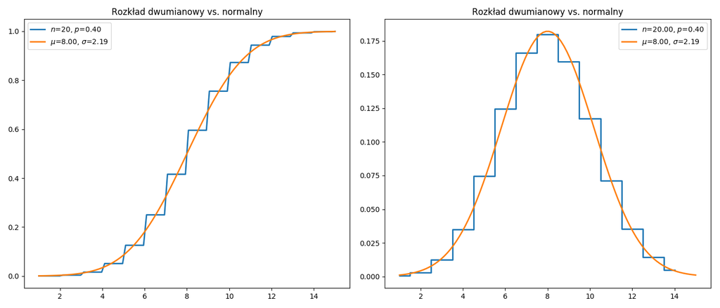

```python
from scipy import *
import scipy.stats as stats
import matplotlib.pyplot as plt

fig = plt.figure(figsize=(14,6))
ax1 = fig.add_subplot(1,2,1)
ax2 = fig.add_subplot(1,2,2)

X = linspace(1,15, 100)
ax1.plot(X, stats.binom.cdf(X, n= 20, p= 0.4), '-', color='C0',
linewidth=2,label='$n$=%.0f, $p$=%.2f' % (20,0.4))
ax1.plot(X, stats.norm.cdf(X, loc= 20*0.4, scale= sqrt(20*0.4*0.6)), '-', color='C1',
linewidth=2,label='$\mu$=%.2f, $\sigma$=%.2f' % (20*0.4, sqrt(20*0.4*0.6)))
ax1.set_title("Rozkład dwumianowy vs. normalny")
ax1.legend()
X = range(1,15)
ax2.plot(X, stats.binom.pmf(X, n= 20, p= 0.4), color='C0',linestyle='steps-mid',
linewidth=2,label='$n$=%.2f, $p$=%.2f' % (20,0.4))
X = linspace(1,15, 100)
ax2.plot(X, stats.norm.pdf(X, loc= 20*0.4, scale= sqrt(20*0.4*0.6)), '-', color='C1',
linewidth=2,label='$\mu$=%.2f, $\sigma$=%.2f' % (20*0.4, sqrt(20*0.4*0.6)))
ax2.set_title("Rozkład dwumianowy vs. normalny")
ax2.legend()
fig.tight_layout()
fig.savefig('binom01.png')
```

Warto zaznaczyć, że w przypadku przybliżania rozkładu dyskretnego (np. dwumianowy) rozkładem normalnym stosujemy poprawkę na ciąglość.
$$P(a-0,5\leq X\leq b+0,5)=\int_{a-0,5}^{b+0,5}N(np,\sqrt{np(1-p)})$$

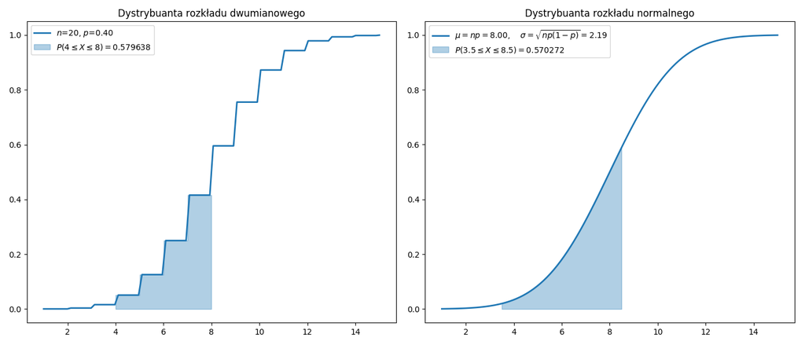

```python
from scipy import *
import scipy.stats as stats
import matplotlib.pyplot as plt

fig = plt.figure(figsize=(14,6))
ax1 = fig.add_subplot(1,2,1)
ax2 = fig.add_subplot(1,2,2)

n = 20
p = 0.4

X = linspace(1,15, 100)
ax1.plot(X, stats.binom.cdf(X, n, p), '-', color='C0',
linewidth=2, label='$n$=%.0f, $p$=%.2f' % (n,p))
ax1.fill_between(x= arange(4,8,0.01), label= '$P(4\leq X\leq 8) = 0.579638$',
                 y1= stats.binom.cdf(arange(4,8,0.01), n, p),
                 facecolor='C0', color='C0', alpha=0.35)
ax1.set_title("Dystrybuanta rozkładu dwumianowego")
ax1.legend()

ax2.plot(X, stats.norm.cdf(X, loc= n*p, scale= sqrt(n*p*(1-p))), '-', color='C0',
linewidth= 2, label= '$\mu=np=$%.2f, $\quad\sigma=\sqrt{np(1-p)}=$%.2f' % (n*p, sqrt(n*p*(1-p))))
ax2.fill_between(x= arange(4-0.5,8+0.5,0.01),  label= '$P(3.5\leq X\leq 8.5) = 0.570272$',
                 y1= stats.norm.cdf(arange(4-0.5,8+0.5,0.01),n*p, sqrt(n*p*(1-p))),
                 facecolor='C0', color='C0', alpha=0.35)
ax2.set_title("Dystrybuanta rozkładu normalnego")
ax2.legend()
fig.tight_layout()
fig.savefig('pois01.png')
```

```python
from scipy import *
import scipy.stats as stats

n= 20; p= 0.4
bin = stats.binom.cdf(8, n= n, p= p)- stats.binom.cdf(3, n= n, p= p)
nor = stats.norm.cdf(8+0.5, loc= n*p, scale= sqrt(n*p*(1-p)))- \
      stats.norm.cdf(4-0.5, loc= n*p, scale= sqrt(n*p*(1-p)))
print('P(4 <= x <= 8): binomial p-value = %.6f, normal p-value = %.6f' % (bin,nor))
```

```
## P(4 <= x <= 8): binomial p-value = 0.579638, normal p-value = 0.570272
```

## 6.2 Rozkład chi-kwadrat

Centralny rozkład chi-kwadrat jest szczególnym przypadkiem niecentralnego rozkładu chi-kwadrat tzn.
$$\chi^2_{df}=\chi^2_{df,\; ncp=0}$$
gdzie:

- dla $\chi^2_{df}$ mamy: $\bar{x}=df$ oraz $s^2=2df$,
- dla $\chi^2_{df,ncp}$ mamy: $\bar{x}=df+ncp$ oraz $s^2=2df+4ncp$.

Rozkład chi-kwadrat to także szczególny przypadek rozkładu gamma:
$$\chi^2_{df}=\Gamma(shape=df/2,\;scale=2)\quad \textrm{lub}\quad\Gamma(shape=df/2,\;rate=1/2)$$
gdzie:

- dla $\Gamma(shape,\;scale)$ mamy: $\bar{x}=shape\cdot scale$ oraz $s^2=shape\cdot scale^2$,
- dla $\Gamma(shape,\;rate)$ mamy: $\bar{x}=shape/rate$ oraz $s^2=shape/rate^2$.

Poniżej przykład oszacowania parametrów rozkładu chi-kwadrat oraz gamma dla zmiennej `c2`.

```python
from scipy import *
import scipy.stats as stats

c2 = stats.chi2.rvs(df= 7, size= 1000, random_state= 2305)
fitC2 = stats.chi2.fit(c2)
logLik = sum(stats.chi2.logpdf(c2, df=fitC2[0], loc=fitC2[1], scale=fitC2[2]))
print('Rozkład chi-kwadrat:')
print('szukane parametry: df= %.6f, loc= %.6f, scale= %.6f' % (fitC2[0], fitC2[1], fitC2[2]))
print('logarytm wairygodności: %.6f' % logLik, '\n')
fitG = stats.gamma.fit(c2)
logLik = sum(stats.gamma.logpdf(c2, a=fitG[0], loc=fitG[1], scale=fitG[2]))
print('Rozkład gamma:')
print('szukane parametry: shape= %.6f, loc= %.6f, scale= %.6f' % (fitG[0], fitG[1], fitG[2]))
print('logarytm wairygodności: %.6f' % logLik)
```

```
## Rozkład chi-kwadrat:
## szukane parametry: df= 6.867740, loc= 0.040242, scale= 0.991986
## logarytm wairygodności: -2616.535734
##
## Rozkład gamma:
## szukane parametry: shape= 3.433912, loc= 0.040211, scale= 1.983955
## logarytm wairygodności: -2616.535734
```

Poniżej przykład obliczenia prawdopodobieństwa $P(X\leq 6)$ dla rozkładu $\chi^2_{df=12}$ oraz $\Gamma(shape=6,\; scale=2)$:

```python
from scipy import *
import scipy.stats as stats

pC2 = stats.chi2.cdf(6, df= 12)
pG = stats.gamma.cdf(6, a= 12/2, scale= 2)
print('Dla rozkładu chi-kwadrat: df= 12:')
print(' P(x<=6) = %.6f' % pC2)
print('Dla rozkładu gamma: shape= 6, loc= 0, scale= 2:')
print(' P(x<=6) = %.6f' % pG)
```

```
## Dla rozkładu chi-kwadrat: df= 12:
##  P(x<=6) = 0.083918
## Dla rozkładu gamma: shape= 6, loc= 0, scale= 2:
##  P(x<=6) = 0.083918
```

## 6.3 Test proporcji

Dla dużych prób i proporcji z próby leżącej pomiędzy $0,2$ a $0,8$ stosujemy asymptotyczny test Score lub Walda.
$$Z_{\textrm{Score}}=\frac{\bar{p}-p_0}{\sqrt{p_0(1-p_0)}}\sqrt{n}
\quad\textrm{lub}\quad
Z_{\textrm{Wald}}=\frac{\bar{p}-p_0}{\sqrt{\bar{p}(1-\bar{p})}}\sqrt{n}$$

Dla danych:
$$n=100,\; m=40 \quad\textrm{czyli}\quad \bar{p}=40/100=0,4$$
przeprowadzimy weryfikscję hipotezy zerowej:
$$H_0:\;p=0,5\quad\textrm{vs}\quad H_1:\;p\neq0,5$$
za pomocą dwóch wyżej wymienionych testów asymptotycznych.

```python
from statsmodels.stats.proportion import *

sol = proportions_ztest(40, 100, value= 0.5)
print('Test Walda: z = %.4f, p-value = %.6f' % (sol[0],sol[1]))
sol = proportions_ztest(40, 100, value= 0.5, prop_var= 0.5)
print('Test Score: z = %.4f, p-value = %.6f' % (sol[0],sol[1]))
```

```
## Test Walda: z = -2.0412, p-value = 0.041227
## Test Score: z = -2.0000, p-value = 0.045500
```

Warto w tym miejscu podkreślić, że opcja uwzględniająca korektę na ciągłość nie została zaimplementowana do funkcji `proportions_ztest` oraz `proportions_chisquare` z pakietu `statsmodels`. Poniżej przykład jak zdefiniować dwustronny test Score oraz Walda z poprawką na ciągłość.

```python
from scipy import *
import scipy.stats as stats

def proportions_ztest_correct(m, n, p0, test="Score"):
    p = m/n
    z_cS = (abs(p-p0)-0.5*(1/n))/sqrt((p0*(1-p0))/n)
    p_cS = 2*(1-stats.norm.cdf(z_cS, loc= 0, scale= 1))
    z_cW = (abs(p-p0)-0.5*(1/n))/sqrt((p*(1-p))/n)
    p_cW = 2*(1-stats.norm.cdf(z_cW, loc= 0, scale= 1))
    if test=="Score": return z_cS,p_cS
    elif test=="Wald": return z_cW,p_cW

sol = proportions_ztest_correct(40, 100, 0.5, test="Wald")
print('Test Walda z korektą: z = %.4f, p-value = %.6f' % (sol[0], sol[1]))
sol = proportions_ztest_correct(40, 100, 0.5, test="Score")
print('Test Score z korektą: z = %.4f, p-value = %.6f' % (sol[0], sol[1]))
```

```
## Test Walda z korektą: z = 1.9392, p-value = 0.052479
## Test Score z korektą: z = 1.9000, p-value = 0.057433
```

Przyjmuje się, że gdy rozmiar próbki jest mały a proporcja z próbki jest mniejsza od $0,2$ lub większa od $0,8$ to stosujemy dokładny test dwumianowy. Dla testu dwustronnego p-wartość obliczamy według wzoru:
$$\textrm{p-value}=2 \cdot \textrm{min}\,\lbrace\,{P(X\geq k,n,p_0),\; P(X\leq k,n,p_0)\,\rbrace}$$

```python
from statsmodels.stats.proportion import *

print('Dokładny test dwumianowy, p-value = %.6f' % binom_test(40, 100, prop= 0.5) )
```

```
## Dokładny test dwumianowy, p-value = 0.056888
```

Warto zwrócić uwagę na fakt, że p-wartość z dokładnego testu dwumianowego jest bardzo zbliżona do p-wartości asymptotycznego testu Score z poprawką na ciągłość.

W literaturze można spotkać różne sposoby wyznaczania mocy testu dla proporcji np. za pomocą dystrybuanty rozkładu dwumianowego:
$$P(X\geq h_1,n,\bar{p})+P(X\leq h_2,n,\bar{p})$$

- dla $\bar{p}\leq p_0$
  $$h_1=\left\lceil np_0-q_{\alpha/2}\sqrt{np_0(1-p_0)}\right\rceil
  \quad\textrm{oraz}\quad
  h_2=\left\lfloor np_0+q_{\alpha/2}\sqrt{np_0(1-p_0)}\right\rfloor$$
- dla $\bar{p}\geq p_0$
  $$h_1=\left\lfloor np_0-q_{\alpha/2}\sqrt{np_0(1-p_0)}\right\rfloor
  \quad\textrm{oraz}\quad
  h_2=\left\lceil np_0+q_{\alpha/2}\sqrt{np_0(1-p_0)}\right\rceil$$

lub za pomocą dystrybuanty rozkładu normalnego $N(0,1)$:
$$\textrm{moc}=P(X\leq h\sqrt{n}-q_{1-\alpha/2})+P(X\leq -h\sqrt{n}-q_{1-\alpha/2})$$
dla $h=\frac{\bar{p}-p_0}{\sqrt{\bar{p}(1-\bar{p})}}$ będziemy mieli:
$$\textrm{moc}=P(X\leq Z_\textrm{Wald}-q_{1-\alpha/2})+P(X\leq -Z_\textrm{Wald}-q_{1-\alpha/2})$$

```python
from statsmodels.stats.proportion import *
from statsmodels.stats.power import *
from scipy import *

h = (0.4-0.5)/sqrt(0.4*0.6)
pow = NormalIndPower().solve_power(h, nobs1=100, alpha=0.05, ratio=0)
print('Moc testu Walda = %.4f'%pow)
```

```
## Moc testu Walda = 0.5324
```

Innym sposobem wyznaczania mocy testu jest wykorzystanie symulacji.

```python
from statsmodels.stats.proportion import *
from scipy import *

B = 10000
resZ = [ proportions_ztest(random.binomial(n=1,p=0.4, size= 100).sum(), 100, value= 0.5) \
       for i in range(B) ]
pvalZ = [ resZ[i][1] for i in range(B) ]
mocZ = mean([ pvalZ[i] <= 0.05 for i in range(B) ])
print ('Symulacyjna moc testu Walda:', ("%.6f" % mocZ))
```

```
## Symulacyjna moc testu Walda: 0.542400
```

W sposób symulacyjny można także wyznaczyć rozkład proporcji oraz statystykę testu.

```
## 95% przedział ufności proporcji:
## [ 0.3  0.5]
## Empiryczny rozkład statystyki testu Walda (bootstrapowa p-watrość dla B = 10000):
## 0.0409
```

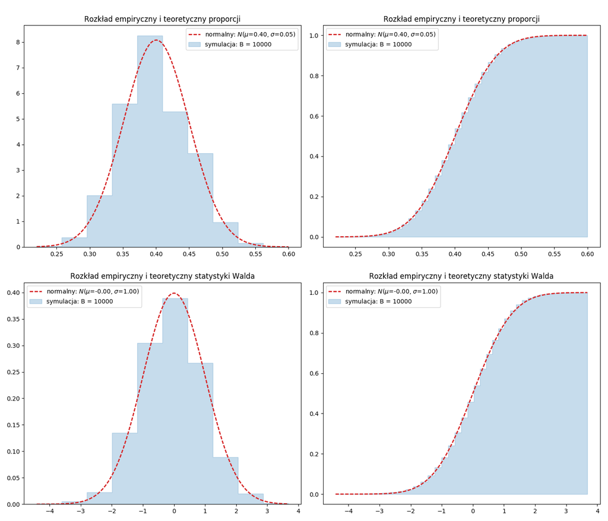

```python
from scipy import *
import scipy.stats as stats
import matplotlib.pyplot as plt
from statsmodels.stats.proportion import *
from statsmodels.distributions.empirical_distribution import ECDF

B = 10000
prop = [ random.binomial(n=100,p=0.4)/100 for i in range(B) ]
test = [ proportions_ztest(random.binomial(n=1,p=0.4, size= 100).sum(), 100, value= 0.5) \
       for i in range(B) ]
test = [ test[i][0] for i in range(B) ]
test = (test-mean(test))/std(test)

fig = plt.figure(figsize=(14,12))
ax1 = fig.add_subplot(2,2,1)
ax2 = fig.add_subplot(2,2,2)
ax3 = fig.add_subplot(2,2,3)
ax4 = fig.add_subplot(2,2,4)

X = linspace(min(prop), max(prop), 100)
N, bins, patches = ax1.hist(prop ,normed=1, facecolor='C0',edgecolor='C0',
                   histtype='stepfilled', alpha=0.25, label='symulacja: B = %.0f' % (B))
ax1.plot(X, stats.norm.pdf(X, loc=mean(prop), scale=std(prop)), '--', color='C3',
linewidth=2,label='normalny: $N(\mu$=%.2f, $\sigma$=%.2f)' % (mean(prop),std(prop)))
ax1.set_title("\nRozkład empiryczny i teoretyczny proporcji")
ax1.legend()

ax2.fill_between(ECDF(prop).x, 0, ECDF(prop).y, color='C0', alpha=0.25,
                 label='symulacja: B = %.0f' % (B))
ax2.plot(X, stats.norm.cdf(X, loc= mean(prop), scale= std(prop)), '--', color='C3',
linewidth=2,label='normalny: $N(\mu$=%.2f, $\sigma$=%.2f)' % (mean(prop), std(prop)))
ax2.set_title("\nRozkład empiryczny i teoretyczny proporcji")
ax2.legend()

X = linspace(min(test), max(test), 100)
N, bins, patches = ax3.hist(test ,normed=1, facecolor='C0',edgecolor='C0',
                   histtype='stepfilled', alpha=0.25, label='symulacja: B = %.0f' % (B))
ax3.plot(X, stats.norm.pdf(X, loc=mean(test), scale=std(test)), '--', color='C3',
linewidth=2,label='normalny: $N(\mu$=%.2f, $\sigma$=%.2f)' % (mean(test),std(test)))
ax3.set_title("\nRozkład empiryczny i teoretyczny statystyki Walda")
ax3.legend()

ax4.fill_between(ECDF(test).x, 0, ECDF(test).y, color='C0', alpha=0.25,
                 label='symulacja: B = %.0f' % (B))
ax4.plot(X, stats.norm.cdf(X, loc= mean(test), scale= std(test)), '--', color='C3',
linewidth=2,label='normalny: $N(\mu$=%.2f, $\sigma$=%.2f)' % (mean(test), std(test)))
ax4.set_title("\nRozkład empiryczny i teoretyczny statystyki Walda")
ax4.legend()

plt.tight_layout()
plt.savefig('prop01.png')

print('95% przedział ufności proporcji:')
print(percentile(prop,(2.5,97.5)))
print('Empiryczny rozkład statystyki testu Walda (bootstrapowa p-watrość dla B = %.0f):' % B)
print('%.4f' % (ECDF(test)(-2.0412)+(1-ECDF(test)(2.0412))) )
```

# 7 Aproksymacja

## 7.1 Model Michaelis-Menten

Jedną z bardziej popularnych metod dopasowywania krzywych do zbioru danych jest nieliniowa metoda najmniejszych kwadratów np. z wykorzystaniem algorytmu Levenberga-Marquardta. Ta metoda jest dostępna w pakiecie `scipy.optimize` – funkcje `leastsq`, `least_squares` oraz `curve_fit`. W przypadku gdy chcemy dodać ograniczenia na szukane parametry musimy wybrać jedną z dwóch opcji: `trf` – trust region reflective algorithm (opcja domyślna) lub `dogbox` – dogleg algorithm. Te dwa algorytmy są przewidziane tylko dla funkcji `least_squares` oraz `curve_fit`. W funkcji `leastsq` jest zaimplementowany tylko algorytm Levenberga-Marquardta.

Postać analityczna modelu:
$$V=\frac{S\cdot V_{max}}{S+K_{m}}$$

```
## Vmax = 5.29092809253 +/- 0.286778084255   5.42 %
##   Km = 1.70184477354 +/- 0.312836236328   18.382 %
##
## degrees of freedom:  7
## chi-square value:  4.424
## reduced chi-square value:  0.632
```

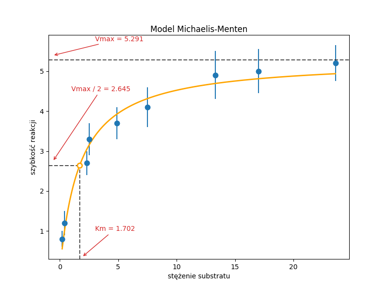

```python
from scipy import *
import matplotlib.pyplot as plt
from scipy.optimize import *

S = array([0.2, 0.4, 2.3, 2.5, 4.9, 7.5, 13.3, 17.0, 23.6])
V = array([0.8, 1.2, 2.7, 3.3, 3.7, 4.1, 4.9, 5.0, 5.2])
w = array([0.2, 0.3, 0.3, 0.4, 0.4, 0.5, 0.6, 0.55, 0.45])

def micmen(S,Vmax,Km):
    return (S*Vmax)/(S+Km)

sol, pcov = curve_fit(micmen, S, V, sigma=w, absolute_sigma=False, p0=(5,2))
print ("Vmax =", sol[0], "+/-", pcov[0,0]**0.5, \
" ", round((pcov[0,0]**0.5/sol[0])*100,3),"%")
print ("  Km =", sol[1], "+/-", pcov[1,1]**0.5, \
" ", round((pcov[1,1]**0.5/sol[1])*100,3),"%" '\n')
df = len(S) - len(sol)
chi_squared = sum(((micmen(S, *sol) - V) / w)**2)
reduced_chi_squared = chi_squared / df
print ('degrees of freedom: ', df)
print ('chi-square value: ', ("%.3f" % chi_squared))
print ('reduced chi-square value: ', ("%.3f" % reduced_chi_squared))

x = arange(0.2,23.6,0.01)
plt.figure(figsize=(8,6))
plt.title('Model Michaelis-Menten')
plt.errorbar(S, V, yerr = w, fmt = '.', ecolor='#1f77b4', color='#1f77b4', markersize=15)
plt.plot(x, micmen(x,*sol), linewidth=2, color="orange")
plt.xlabel(u'stężenie substratu')
plt.ylabel(u'szybkość reakcji')
plt.axvline(x=sol[1],ymax=0.4,color='k',linestyle='--',linewidth=1)
plt.axhline(y=sol[0]/2,xmax=0.1,color='k',linestyle='--',linewidth=1)
plt.axhline(y=sol[0],color='k',linestyle='--',linewidth=1)
plt.plot(sol[1],sol[0]/2,'o',color='orange',markersize=8)
plt.plot(sol[1],sol[0]/2,'.',color='white',markersize=8)
plt.annotate('Vmax / 2 = %.3f' % (sol[0]/2),xy=(0-0.6,sol[0]/2+0.1),xytext=(1,4.5),\
 arrowprops=dict(arrowstyle='->',color='#d62728'),color='#d62728')
plt.annotate('Km = %.3f' % (sol[1]),xy=(sol[1]+0.2,0.25+0.1),xytext=(3,1),\
 arrowprops=dict(arrowstyle='->',color='#d62728'),color='#d62728')
plt.annotate('Vmax = %.3f' % (sol[0]),xy=(0-0.6,sol[0]+0.1),xytext=(3,5.75),\
 arrowprops=dict(arrowstyle='->',color='#d62728'),color='#d62728')
plt.savefig("micmen01.png")
```

## 7.2 Model odporny

W pakiecie `kapteyn` jest dostępna funkcja `kmpfit` dzięki której szukane parametry modelu możemy wyznaczyć na podstawie wybranego kreterium optymalizacji:

- minimalizacja sumy kwadratów reszt:

$$\sum_{i=1}^{n}\left(\frac{y_i-f}{\sigma_i}\right)^2$$

- minimalizacja sumy wartości bezwzględnych reszt:

$$\sum_{i=1}^{n}\frac{|y_i-f|}{\sigma_i}$$

```
##
## ==== Robust estimation model ====
## Params:  [5.7443334316605954, 2.470436343321075]
## Stderr:  [ 0.15208103  0.23023822]
## Chi^2 min:  8.879481604048097
##
## ==== Classic estimation model ====
## Params:  [6.039707051014882, 2.3418962277362101]
## Stderr:  [ 0.64647947  0.77766233]
## Chi^2 min:  16.910065512023017
```

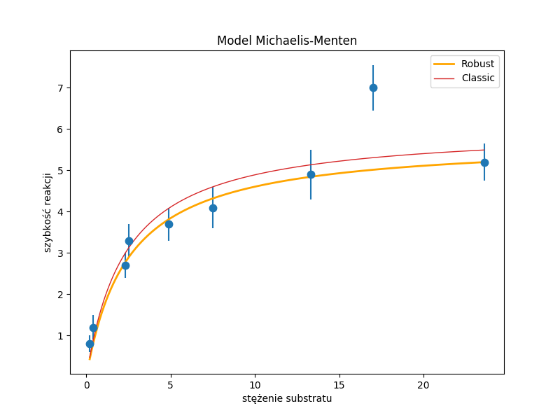

```python
from scipy import *
import matplotlib.pyplot as plt
from kapteyn import kmpfit

def model(p, data):
   Vmax, Km = p
   y = (x*Vmax)/(x+Km)
   return y

def fun(p, data):
   x, y = data
   Vmax, Km = p
   model = (x*Vmax)/(x+Km)
   return (y-model)/w

def rob(p, data):
   x, y = data
   Vmax, Km = p
   model = (x*Vmax)/(x+Km)
   return sqrt(abs(y-model)/w)

S = array([0.2, 0.4, 2.3, 2.5, 4.9, 7.5, 13.3, 17.0, 23.6])
V = array([0.8, 1.2, 2.7, 3.3, 3.7, 4.1, 4.9, 7.0, 5.2])
w = array([0.2, 0.3, 0.3, 0.4, 0.4, 0.5, 0.6, 0.55, 0.45])

frob = kmpfit.Fitter(rob, params0=[5,2], data=(S,V))
frob.fit()

ffun = kmpfit.Fitter(fun, params0 = [5,2], data=(S,V))
ffun.fit()

print ("\n==== Robust estimation model ====")
print ("Params: ", frob.params)
print ("Stderr: ", frob.stderr)
print ("Chi^2 min: ", frob.chi2_min)

print ("\n==== Classic estimation model ====")
print ("Params: ", ffun.params)
print ("Stderr: ", ffun.stderr)
print ("Chi^2 min: ", ffun.chi2_min)

x = arange(0.2,23.6,0.01)
plt.figure(figsize=(8,6))
plt.title('Model Michaelis-Menten')
plt.errorbar(S, V, yerr = w, fmt = '.', ecolor='#1f77b4', color='#1f77b4', markersize=15)
plt.plot(x, model(frob.params,S), linewidth=2, color="orange",label="Robust")
plt.plot(x, model(ffun.params,S), linewidth=1, color="C3",label="Classic")
plt.legend()
plt.xlabel(u'stężenie substratu')
plt.ylabel(u'szybkość reakcji')
plt.savefig("robust01.png")
```

```
## Classic: Vmax = 6.4873, Km = 2.9714
## Huber:   Vmax = 5.7355, Km = 2.3583
```

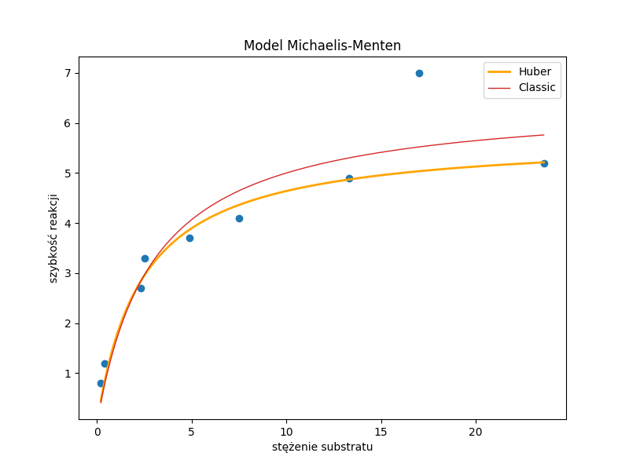

```python
from scipy import *
import matplotlib.pyplot as plt
from scipy.optimize import least_squares

def model(p, data):
   Vmax, Km = p
   y = (x*Vmax)/(x+Km)
   return y

def fun(x, t, y):
    return ((t*x[0])/(t+x[1]))-y

x0 = array([ 2.,  1.])

S = array([0.2, 0.4, 2.3, 2.5, 4.9, 7.5, 13.3, 17.0, 23.6])
V = array([0.8, 1.2, 2.7, 3.3, 3.7, 4.1, 4.9, 7.0, 5.2])

res_robust = least_squares(fun, x0, loss='soft_l1', f_scale=0.1, args=(S, V))
res_class = least_squares(fun, x0, args=(S, V))
print('Classic: Vmax = %.4f, Km = %.4f' % (res_class.x[0],res_class.x[1]))
print('Huber:   Vmax = %.4f, Km = %.4f' % (res_robust.x[0],res_robust.x[1]))

x = arange(0.2,23.6,0.01)
plt.figure(figsize=(8,6))
plt.title('Model Michaelis-Menten')
plt.plot(S, V, 'o')
plt.plot(x, model(res_robust.x,S), linewidth=2, color="orange",label="Huber")
plt.plot(x, model(res_class.x,S), linewidth=1, color="C3",label="Classic")
plt.legend()
plt.xlabel(u'stężenie substratu')
plt.ylabel(u'szybkość reakcji')
plt.savefig("robust02.png")
```

## 7.3 Model Voigt

Pakiet `lmfit` zawiera pewne ułatwienia w dopasowywaniu krzywych do danych. Jednym z nich jest szereg wbudowanych funkcji np. model Voigta.
$$V=\frac{\mathrm{Re}\left[\exp(-z^2) \mathrm{erfc}(-iz)\right]\;A}{\sigma\sqrt{2\pi}}$$
gdzie: $z=\frac{x-\mu+i \gamma}{\sigma\sqrt{2}}$

Dzięki temu nie musimy podawać postaci analitycznej funkcji. Dodatkowo możemy zdecydować o automatycznym doborze parametrów startowych. Warto też wspomnieć o funkcji `minimize` która w porównaniu do funkcji `fit` oferuje większą liczby algorytmów np. Sequential Linear Squares Programming.

```
## [[Model]]
##     Model(voigt)
## [[Fit Statistics]]
##     # function evals   = 19
##     # data points      = 110
##     # variables        = 3
##     chi-square         = 9.120
##     reduced chi-square = 0.085
##     Akaike info crit   = -267.902
##     Bayesian info crit = -259.801
## [[Variables]]
##     amplitude:   23.0854679 +/- 0.367235 (1.59%) (init= 27.71622)
##     sigma:       1.06724765 +/- 0.022152 (2.08%) (init= 1.1375)
##     center:      6.22026928 +/- 0.029921 (0.48%) (init= 6.297143)
##     gamma:       1.06724765 +/- 0.022152 (2.08%)  == 'sigma'
##     fwhm:        3.84348964 +/- 0.079777 (2.08%)  == '3.6013100*sigma'
##     height:      8.62945883 +/- 0.135545 (1.57%)  == '0.3989423*amplitude/max(1.e-15, sigma)'
## [[Correlations]] (unreported correlations are <  0.100)
##     C(amplitude, sigma)          =  0.662
```

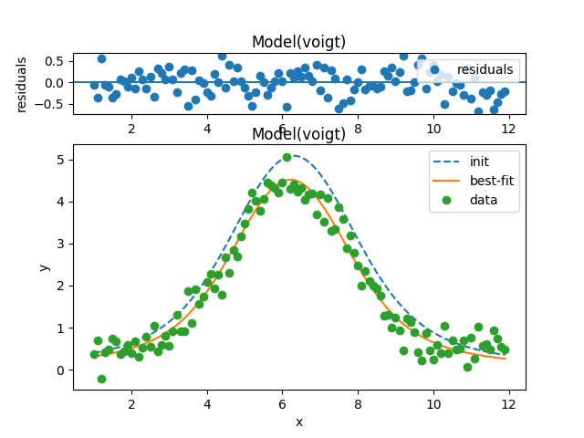

```python
import matplotlib.pyplot as plt
from scipy import *
from lmfit import *
from lmfit.models import *

x = arange(1,12,0.1)
random.seed(2307)
y = 0.4+4*exp(-(x-6.2)**2/(2*1.5**2))+ random.normal(0,0.25,size=len(x))+0.1
mod = VoigtModel()
pars = mod.guess(y, x=x)
out = mod.fit(y, pars, x=x)
print(out.fit_report())

plt.figure(figsize=(8,6))
out.plot()
plt.savefig('voigt01.png')
```

Więcej informacji na temat tego pakietu można znaleźć po adresem:

- https://lmfit.github.io/lmfit-py/

# 8 Interpolacja a krzywa Beziera

W pakiecie `scipy.interpolate` jest zaimplementowanych kilka ciekawych funkcji do interpolacji danych. Poniżej kilka przykladowych metod interpolacji danych niemonotonicznych oraz monotonicznych czyli takich w których punkty zachowują określony porządek.

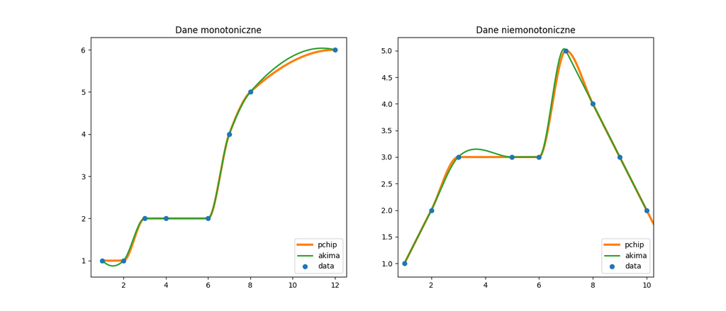

```python
import matplotlib.pyplot as plt
from scipy import *
from scipy.interpolate import *

xp = [1,2,3,4,6,7,8,12]
yp = [1,1,2,2,2,4,5,6]
Xp = [1,2,3,5,6,7,8,9,10]
Yp = [1,2,3,3,3,5,4,3,2]

xv = arange(1,12,0.01)

fig = plt.figure(figsize=(14,6))
ax1 = fig.add_subplot(1,2,1)
ax2 = fig.add_subplot(1,2,2)
ax1.plot(xv,PchipInterpolator(xp, yp)(xv),\
         linewidth=3,color="C1",label="pchip")
ax1.plot(xv,Akima1DInterpolator(xp, yp)(xv),\
         linewidth=2,color="C2",label="akima")
ax1.plot(xp,yp,'o',color="C0",label="data")
ax1.set_title("Dane monotoniczne")
ax1.legend(loc='lower right')
ax2.plot(xv,PchipInterpolator(Xp, Yp)(xv),\
         linewidth=3,color="C1",label="pchip")
ax2.plot(xv,Akima1DInterpolator(Xp, Yp)(xv),\
         linewidth=2,color="C2",label="akima")
ax2.plot(Xp,Yp,'o',color="C0",label="data")
ax2.set_xlim(0.75,10.25)
ax2.set_ylim(0.75,5.25)
ax2.set_title("Dane niemonotoniczne")
ax2.legend(loc='lower right')
fig.savefig('inter01.png')
```

Warto w tym miejscu przedstawić również krzywą Beziera. Ta metoda interpoluje tylko punkt początkowy i końcowy a pozostałe (punkty pośrednie) aproksymuje. Poniżej przykład dla danych nieposortowanych oraz posortowanych.

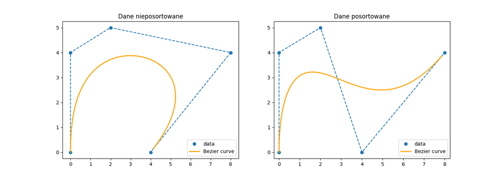

```python
from scipy import *
from pandas import *
import matplotlib.pyplot as plt
from scipy.stats import *

t = arange(0,1,0.01)
d = DataFrame({'x' :[0,0,2,8,4], 'y' :[0,4,5,4,0]})
px = [sum(binom.pmf(arange(0,5,1),4,i)*list(d['x']))
     for i in t]
py = [sum(binom.pmf(arange(0,5,1),4,i)*list(d['y']))
     for i in t]

D = d.sort_values(by=['x'], ascending=[True])
Px = [sum(binom.pmf(arange(0,5,1),4,i)*list(D['x']))
     for i in t]
Py = [sum(binom.pmf(arange(0,5,1),4,i)*list(D['y']))
     for i in t]

fig = plt.figure(figsize=(14,5))
ax1 = fig.add_subplot(1,2,1)
ax2 = fig.add_subplot(1,2,2)
ax1.plot(d['x'],d['y'],'--',label="")
ax1.plot(d['x'],d['y'],'o',color="C0",label="data")
ax1.plot(px,py,linewidth=2,color="orange",label="Bezier curve")
ax1.set_title("Dane nieposortowane")
ax1.legend(loc='lower right')
ax2.plot(D['x'],D['y'],'--',label="")
ax2.plot(D['x'],D['y'],'o',color='C0',label="data")
ax2.plot(Px,Py,linewidth=2,color="orange",label="Bezier curve")
ax2.set_xlim(-0.25,8.25)
ax2.set_ylim(-0.25,5.25)
ax2.set_title("Dane posortowane")
ax2.legend(loc='lower right')
fig.savefig('Bezier01.png')
```